# Analyse de la Croissance des plantes : Application de l’ANOVA à mesures répétées

[figure not shown]

# Analyse de Croissance des Plantes

[figure not shown]

**Auteurs :** ILLY Jacques & ZINABA Albert | **Enseignant :** M. A. Carlos | **ISE 2** | **Date :** 27 février 2026

# **Introduction**

Dans le cadre de l’*expérimentation agronomique*, la détermination des facteurs influençant la croissance *végétale* exige une rigueur statistique capable de distinguer les effets réels des traitements des fluctuations naturelles de l’environnement. L’**Analyse de la Variance (ANOVA) à mesures répétées** s’impose ici comme l’outil de référence, offrant une puissance de détection supérieure en isolant la variabilité liée aux cycles de répétition pour se concentrer sur le “signal” produit par les facteurs contrôlés. Contrairement à une *ANOVA simple* qui suppose que chaque échantillon est prélevé dans un environnement identique, l’ANOVA à mesures répétées intègre la notion de **variabilité temporelle ou spatiale**. En statistique, on parle de plan en **blocs**. Chaque **“répétition”** agit comme un bloc qui contient toutes les combinaisons de nos facteurs.

L’objectif central de ce travail est d’appliquer ce modèle robuste à l’étude de l’interaction entre trois types de terreaux *(Manguier, Caïlcédrat, Anacarde)* et deux variétés de plantes, afin d’identifier scientifiquement l’association optimale capable de maximiser le rendement de croissance tout en garantissant la reproductibilité des résultats. On veux s’assurer que si la “Répétition n°3” a globalement mieux réussi que la “Répétition n°1” (à cause de la température de la serre ou du moment de l’arrosage), cette différence ne soit pas attribuée par erreur aux terreaux.

# **I. Exemple introductif**

**Le défi de l’agronome face à la variabilité**

Imaginons un chercheur en agronomie, **Monsieur Diallo**, qui travaille sur la restauration des sols. Il est convaincu que les résidus de feuilles d’arbres locaux *(Manguier, Caïlcédrat et Anacarde)* peuvent constituer des terreaux fertiles capables de booster la croissance de deux variétés de plantes spécifiques. Pour le vérifier, il ne se contente pas d’une seule observation : il met en place une expérience rigoureuse en plantant des lots de ces deux variétés dans chacun des trois terreaux.

Cependant, au moment de récolter ses mesures, **Monsieur Diallo** fait face à la réalité complexe du terrain. Dans sa serre, la *lumière* n’est pas tout à fait la même d’un coin à l’autre, et l*’humidité* a légèrement varié entre le début et la fin de son étude. Pour ne pas être trompé par ces facteurs extérieurs, il décide de répéter toute l’opération **quatre fois** de suite. À la fin, il se retrouve avec une montagne de chiffres *(notre base de données Excel)* où le nombre de plantes par lot varie, car certaines n’ont pas survécu ou n’ont pas germé.

Face à ces données brutes, les questions auxquelles nous devrons répondre pour conclure ce travail sont les suivantes :

**L’effet Terreau** : Existe-t-il un type de terreau qui, indépendamment de la variété, produit systématiquement des plantes plus hautes ?

**L’effet Variété** : L’une des deux variétés possède-t-elle un potentiel de croissance naturellement supérieur à l’autre ?

**L’interaction (Le “Mix” Gagnant)** : Existe-t-il une association spécifique entre un terreau et une variété (par exemple, le Manguier avec la Variété 2) qui crée une synergie exceptionnelle pour la croissance ?

**La fiabilité** : Les différences observées sont-elles suffisamment stables à travers les quatre répétitions pour être jugées statistiquement significatives, ou sont-elles simplement dues au hasard ?

# **II. Description des données**

## **1. Structure Initiale des Données (Format “Large”)**

La base de données brute, telle qu’extraite du protocole d’expérimentation, se présente sous un format *matriciel complexe*. Les mesures de hauteur sont réparties dans des colonnes nommées par le code de la répétition et du traitement (ex: 1Ma, 2Ma).

Cette structure présente deux caractéristiques majeures :

*Un codage visuel des variétés* : L’appartenance d’une plante à la Variété 1 *(fond blanc)* ou à la Variété 2 *(fond jaune)* est indiquée par la couleur de la cellule, ce qui est illisible pour un logiciel de statistique.

*Un plan non équilibré* : Le nombre de lignes par colonne varie (lots de tailles inégales), ce qui signifie que le nombre de plantes ayant survécu ou germé n’est pas identique pour chaque combinaison Terreau × Variété.

## **2. Méthodologie de Réorganisation (Format “Long”)**

Pour mener à bien l’ANOVA, nous devons transformer ces données *“non structurées”* en un format *“Tidy Data”*. Dans ce format, chaque ligne représente une unité expérimentale unique (*une plante*) et chaque colonne représente une variable.

La base sera réorganisée selon les quatre variables suivantes :

Variété (Facteur Qualitatif) : *“Var1” ou “Var2”*.

Terreau (Facteur Qualitatif) : *“Manguier”, “Caïlcédrat” ou “Anacarde”*.

Répétition (Facteur Bloc) : *Identifiant de la vague d’expérience (1, 2, 3 ou 4).*

Hauteur (Variable Quantitative) : *La mesure numérique exprimée en cm.*

[Consulter la base de données organisée](https://docs.google.com/spreadsheets/d/1Dhr3_mCabZA2W5I7vMrxffSfFQlmgOWN/edit?usp=drive_link&ouid=117434889517307286873&rtpof=true&sd=true)

## **3. Intérêt de la Restructuration**

Cette transformation est indispensable pour plusieurs raisons :

*Identification des Interactions* : Elle permet de croiser mathématiquement chaque type de terreau avec chaque variété.

*Prise en compte des blocs* : Elle permet d’isoler la variance liée aux répétitions, traitant ainsi les 4 vagues comme des blocs aléatoires pour purifier l’effet des traitements.

*Compatibilité logicielle* : C’est la structure standard requise pour l’utilisation de bibliothèques d’analyse sous R (comme lme4 ou car) ou Python (statsmodels).

# **III. Etude théorique de l’ANOVA à mesure répété**

## **1. Position du problème et Notation**

Dans l’expérience de Monsieur Diallo, nous étudions la hauteur des plantes ($Y$) soumises à deux facteurs fixes :

Le dispositif est dit “à mesures répétées” car chaque combinaison (Terreau $\times$ Variété) est testée au sein de $k=4$ **Répétitions** (notées $\gamma$). Ces répétitions agissent comme des **blocs**.

Soit $Y_{ijk\ell}$ la hauteur de la $\ell$-ième plante de la variété $i$, dans le terreau $j$, pour la répétition $k$.

## **2. Analyse Descriptive : Calcul des Moyennes**

Avant de procéder à l’analyse de la variance, il est fondamental de définir les estimateurs des moyennes. Ces valeurs servent de points de référence pour le calcul des écarts et permettent à Monsieur Diallo d’observer les premières tendances de croissance.

### **a. Moyenne Générale ($\bar{Y}_{\dots}$)**

Elle représente la hauteur moyenne de l’ensemble des $N$ plantes de l’expérience, toutes variétés, tous terreaux et toutes répétitions confondus :

$$\bar{Y}_{\dots} = \frac{1}{N}
\sum_{i=1}^{a} \sum_{j=1}^{b} \sum_{k=1}^{K} \sum_{l=1}^{n_{ijk}}
Y_{ijkl}$$

### **b. Moyennes Marginales (Effets Principaux)**

Ces moyennes permettent d’isoler l’influence globale de chaque facteur indépendamment de l’autre.

- **Moyenne de la Variété $i$** : Elle mesure le potentiel de croissance intrinsèque de chaque variété.
  $$\bar{Y}_{i\dots} = \frac{1}{n_i} \sum_{j,k,l}
  Y_{ijkl}$$
- **Moyenne du Terreau $j$** : Elle mesure l’efficacité globale d’un substrat (Manguier, Caïlcédrat ou Anacarde).
  $$\bar{Y}_{\cdot j \dots} = \frac{1}{n_j}
  \sum_{i,k,l} Y_{ijkl}$$

### **c. Moyennes Croisées (Interaction Terreau $\times$ Variété)**

Elles sont cruciales pour identifier le “mix” optimal. Elles permettent de voir si une variété spécifique réagit mieux à un terreau donné :

$$\bar{Y}_{ij\cdot\cdot} =
\frac{1}{n_{ij}} \sum_{k,l} Y_{ijkl}$$

### **d. Moyenne du Bloc (Répétition $k$)**

Cette moyenne mesure le niveau de croissance lors de la vague d’expérimentation $k$. Elle permet de quantifier l’effet “bloc” (variations environnementales de la serre lors de chaque répétition) :

$$\bar{Y}_{\cdot\cdot k \cdot} =
\frac{1}{n_k} \sum_{i,j,l} Y_{ijkl}$$

## **2. Modélisation Mathématique**

### **A. Le Modèle Linéaire Simple (ANOVA Factorielle)**

### **a. Le Modèle**

Le modèle statistique adapté à notre exemple est un modèle linéaire à effets fixes avec un facteur de bloc aléatoire :

$$Y_{ijk\ell} = \mu + \alpha_i + \beta_j +
(\alpha\beta)_{ij} + \gamma_k + \epsilon_{ijk\ell}$$

Où :

- $\mu$ : La moyenne globale de la hauteur.
- $\alpha_i$ : L’effet propre à la **Variété** $i$.
- $\beta_j$ : L’effet propre au **Terreau** $j$.
- $(\alpha\beta)_{ij}$ : L’effet d’**interaction** (le “mix” spécifique terreau/variété).
- $\gamma_k$ : L’effet du bloc (**Répétition** $k$). Il capte la variabilité du dispositif expérimental lors de la vague $k$.
- $\epsilon_{ijk\ell}$ : L’erreur résiduelle (la variabilité entre les plantes d’un même pot).

### **b. Décomposition de la Variance (Moyennes Carrées)**

L’équation fondamentale de la décomposition est :

$$SS_{Totale} = SS_{Variété} +
SS_{Terreau} + SS_{Interaction} + SS_{Bloc} + SS_{Erreur}$$

Voici les formules de calcul détaillées pour chaque composante :

**i. Somme des Carrés Totale ($SS_{T}$)**

Elle mesure la dispersion globale de toutes les hauteurs mesurées par rapport à la moyenne générale :

$$SS_{T} = \sum_{i=1}^{a} \sum_{j=1}^{b}
\sum_{k=1}^{K} \sum_{l=1}^{n_{ijk}} (Y_{ijkl} -
\bar{Y}_{\dots})^2$$

**ii. Somme des Carrés de la Variété ($SS_{Var}$)**

Elle représente la part de variabilité expliquée par la différence entre les deux variétés de plantes :

$$SS_{Var} = \sum_{i=1}^{a} n_i
(\bar{Y}_{i\dots} - \bar{Y}_{\dots})^2$$

**iii. Somme des Carrés du Terreau ($SS_{Ter}$)**

Elle représente la part de variabilité due à l’utilisation des trois types de substrats (Manguier, Caïlcédrat, Anacarde) :

$$SS_{Ter} = \sum_{j=1}^{b} n_j
(\bar{Y}_{\cdot j \dots} - \bar{Y}_{\dots})^2$$

**iv. Somme des Carrés de l’Interaction ($SS_{Int}$)**

C’est la part de variance qui n’est expliquée ni par la variété seule, ni par le terreau seul. Elle révèle si un terreau spécifique profite davantage à une variété donnée :

$$SS_{Int} = \sum_{i=1}^{a} \sum_{j=1}^{b}
n_{ij} (\bar{Y}_{ij\dots} - \bar{Y}_{i\dots} - \bar{Y}_{\cdot j \dots} +
\bar{Y}_{\dots})^2$$

**v. Somme des Carrés du Bloc/Répétition ($SS_{Bloc}$)**

C’est ici que l’on isole l’effet des « mesures répétées ». En extrayant cette variance, on neutralise l’impact des conditions changeantes entre les 4 vagues d’expérience :

$$SS_{Bloc} = \sum_{k=1}^{K} n_k
(\bar{Y}_{\cdot\cdot k \cdot} - \bar{Y}_{\dots})^2$$

**vi. Somme des Carrés de l’Erreur ($SS_{Err}$)**

Elle s’obtient généralement par soustraction ($SS_{Err} = SS_{T} - [SS_{Var} + SS_{Ter} + SS_{Int} + SS_{Bloc}]$). Sa formule théorique représente la somme des carrés des résidus au sein de chaque combinaison :

$$SS_{Err} = \sum_{i,j,k,l} (Y_{ijkl} -
\bar{Y}_{ij\dots} - \gamma_k)^2$$

### **c. Carrés Moyens, Hypothèses et Statistiques de Test**

Pour déterminer si les différences observées par Monsieur Diallo sont statistiquement significatives, nous passons du calcul des Sommes des Carrés (SS) à celui des Carrés Moyens (MS) afin de construire les statistiques de test de Fisher.

### **i. Les Carrés Moyens ($MS$)**

Le Carré Moyen est une estimation de la variance pour chaque source de variation. Il s’obtient en divisant la Somme des Carrés par son degré de liberté ($ddl$) respectif :

$$MS_{Facteur} =
\frac{SS_{Facteur}}{ddl_{Facteur}}$$

### **ii. Hypothèses des Tests**

Pour chaque facteur, nous testons une hypothèse nulle ($H_0$) contre une hypothèse alternative ($H_1$).

*- Effet du Terreau*

- **$H_0$** : Les trois types de terreaux (Manguier, Caïlcédrat, Anacarde) ont le même effet sur la croissance.
- **$H_1$** : Au moins un terreau produit une croissance significativement différente des autres.

*- Effet de la Variété*

- **$H_0$** : Il n’y a pas de différence de hauteur moyenne entre la Variété 1 et la Variété 2.
- **$H_1$** : Une variété possède un potentiel de croissance supérieur à l’autre.

*- Effet de l’Interaction (Terreau $\times$ Variété)*

- **$H_0$** : L’effet du terreau est identique pour les deux variétés (les courbes de réponse sont parallèles).
- **$H_1$** : Il existe une synergie spécifique entre certains terreaux et certaines variétés.

### **iii. La Statistique de Fisher ($F$)**

La validité de nos hypothèses est testée en calculant le ratio de Fisher. Ce ratio compare la variance expliquée par le facteur à la variance résiduelle (le hasard) :

$$F_{calculé} =
\frac{MS_{Facteur}}{MS_{Erreur}}$$

### **d. Règle de Décision**

Pour chaque test, nous observons la **p-valeur** associée :

1. Si **$p < 0,05$** : On rejette $H_0$. Monsieur Diallo peut affirmer avec un risque d’erreur de 5 % que le facteur a un impact réel sur la croissance.
2. Si **$p \geq 0,05$** : On ne rejette pas $H_0$. La différence observée est considérée comme le fruit du hasard ou de la variabilité naturelle.

### **e. Degrés de liberté (ddl)**

Les degrés de liberté utilisés pour les calculs sont :

- $ddl_{Variete} = a - 1$
- $ddl_{Terreau} = b - 1$
- $ddl_{Interaction} = (a - 1)(b - 1)$
- $ddl_{Bloc} = k - 1$
- $ddl_{Erreur} = N - (a \times b) - (k - 1)$

### **f. Tableau de l’ANOVA**

| Source de Variation | ddl | Somme des Carrés (SS) | Carrés Moyens (MS) | F (Valeur de test) |
| --- | --- | --- | --- | --- |
| **Variété** | $a - 1$ | $SS_{Var}$ | $MS_{Var} = \frac{SS_{Var}}{ddl_{Var}}$ | $F_{Var} = \frac{MS_{Var}}{MS_{Err}}$ |
| **Terreau** | $b - 1$ | $SS_{Ter}$ | $MS_{Ter} = \frac{SS_{Ter}}{ddl_{Ter}}$ | $F_{Ter} = \frac{MS_{Ter}}{MS_{Err}}$ |
| **Interaction** | $(a-1)(b-1)$ | $SS_{Int}$ | $MS_{Int} = \frac{SS_{Int}}{ddl_{Int}}$ | $F_{Int} = \frac{MS_{Int}}{MS_{Err}}$ |
| **Bloc (Répétition)** | $k - 1$ | $SS_{Bloc}$ | $MS_{Bloc} = \frac{SS_{Bloc}}{ddl_{Bloc}}$ | - |
| **Erreur** | par soustr. | $SS_{Err}$ | $MS_{Err} = \frac{SS_{Err}}{ddl_{Err}}$ |  |
| **Total** | $N - 1$ | $SS_{Tot}$ |  |  |

### **B. Le Modèle Mixte Amélioré (Structure de Satterthwaite)**

### **a. Le modèle**

Afin d’isoler précisément l’influence des facteurs fixes de la variabilité liée au dispositif expérimental, nous utilisons un modèle linéaire mixte à structures d’erreurs imbriquées :

$$Y_{isj\ell} = \mu + \alpha_i + \beta_j +
(\alpha\beta)_{ij} + \tau_s + (\alpha\tau)_{is} + (\beta\tau)_{js} +
\epsilon_{isj\ell}$$

### **Définition des paramètres :**

- **$\mu$** : La moyenne globale de la hauteur des plants.
- **$\alpha_i$** : L’effet fixe de la **Variété** $i$ ($i=1,..,a$).
- **$\beta_j$** : L’effet fixe du **Terreau** $j$ ($j=1,..,b$).
- **$(\alpha\beta)_{ij}$** : L’effet d’**interaction fixe** entre la variété et le terreau.
- **$\tau_s$** : L’effet aléatoire du bloc (**Répétition**) $s$ ($s=1,..,s$), où $\tau_s \sim \mathcal{N}(0, \sigma^2_\tau)$.
- **$(\alpha\tau)_{is}$** : L’interaction aléatoire **Variété $\times$ Répétition**. Elle mesure la stabilité de l’effet variété à travers les répétitions.
- **$(\beta\tau)_{js}$** : L’interaction aléatoire **Terreau $\times$ Répétition**. Elle mesure la stabilité de l’effet terreau à travers les répétitions.
- **$\epsilon_{isj\ell}$** : L’erreur résiduelle (variabilité intra-groupe).

### **Contraintes d’identifiabilité**

Pour garantir l’unicité de la solution des estimateurs et permettre une interprétation des effets comme des écarts à la moyenne générale, nous imposons les contraintes de somme nulle :

$$\sum_{i=1}^{a} \alpha_i = 0 \quad ;
\quad \sum_{j=1}^{b} \beta_j = 0 \quad ; \quad \sum_{i,j}
(\alpha\beta)_{ij} = 0$$

### **b. Décomposition de la Variance (Somme des Carrés)**

L’équation fondamentale de la décomposition pour ce modèle mixte expert permet d’isoler la variabilité propre aux facteurs fixes de celle liée aux répétitions :

$$SS_{Totale} = SS_{Var} + SS_{Ter} +
SS_{Int} + SS_{Bloc} + SS_{Var \times Bloc} + SS_{Ter \times Bloc} +
SS_{Res}$$

### **c. Formules de calcul détaillées :**

**i. Somme des Carrés de la Variété ($SS_{Var}$)** Elle mesure l’effet global du facteur Variété sur la croissance :

$$SS_{Var} = \sum_{i=1}^{a} n_i
(\bar{Y}_{i\dots\dots} - \bar{Y}_{\dots\dots\dots})^2$$

**ii. Somme des Carrés du Terreau ($SS_{Ter}$)** Elle mesure l’efficacité globale des différents types de substrats :

$$SS_{Ter} = \sum_{j=1}^{b} n_j
(\bar{Y}_{\cdot j \dots\dots} -
\bar{Y}_{\dots\dots\dots})^2$$

**iii. Somme des Carrés de l’Interaction Fixe ($SS_{Int}$)** Elle mesure si la réponse au terreau dépend de la variété utilisée :

$$SS_{Int} = \sum_{i=1}^{a} \sum_{j=1}^{b}
n_{ij} (\bar{Y}_{ij\dots\dots} - \bar{Y}_{i\dots\dots} - \bar{Y}_{\cdot
j \dots\dots} + \bar{Y}_{\dots\dots\dots})^2$$

**iv. Somme des Carrés du Bloc/Répétition ($SS_{Bloc}$)** Elle isole la variabilité brute entre les différentes vagues d’expérience :

$$SS_{Bloc} = \sum_{k=1}^{K} n_k
(\bar{Y}_{\dots k \dots} - \bar{Y}_{\dots\dots\dots})^2$$

**v. Somme des Carrés de l’Interaction Variété $\times$ Bloc ($SS_{Var \times Bloc}$)** Elle mesure la stabilité de l’effet “Variété” d’une répétition à l’autre. C’est le dénominateur utilisé pour le test de Fisher de la Variété :

$$SS_{Var \times Bloc} = \sum_{i=1}^{a}
\sum_{k=1}^{K} n_{ik} (\bar{Y}_{ik\dots\dots} - \bar{Y}_{i\dots\dots} -
\bar{Y}_{\dots k \dots} + \bar{Y}_{\dots\dots\dots})^2$$

**vi. Somme des Carrés de l’Interaction Terreau $\times$ Bloc ($SS_{Ter \times Bloc}$)** Elle mesure la stabilité de l’effet “Terreau” d’une répétition à l’autre :

$$SS_{Ter \times Bloc} = \sum_{j=1}^{b}
\sum_{k=1}^{K} n_{jk} (\bar{Y}_{\cdot jk \dots} - \bar{Y}_{\cdot j
\dots\dots} - \bar{Y}_{\dots k \dots} +
\bar{Y}_{\dots\dots\dots})^2$$

> **NB :** La notation par points ($\cdot$) utilisée dans les expressions des sommes des carrés ($\bar{Y}_{\cdot j \dots}$ et $\bar{Y}_{\dots \dots}$) suit la convention de **sommation généralisée**. Le surplus de points représente l’agrégation (moyennage) sur l’ensemble des dimensions stochastiques du plan d’expérience (individus, répétitions temporelles, blocs). Cette notation exhaustive garantit la validité de la formulation théorique pour tout plan d’expérience multidimensionnel, indiquant que le calcul de la moyenne s’opère sur toutes les dimensions non indicées.

**vii. Somme des Carrés de l’Erreur Résiduelle ($SS_{Res}$)**

Contrairement aux autres composantes qui mesurent des écarts entre moyennes de groupes, l’erreur résiduelle mesure la variabilité intrinsèque entre les plantes d’une même unité expérimentale (même variété, même terreau, même répétition).

Sa formule théorique représente la somme des carrés des écarts de chaque observation individuelle par rapport à la moyenne de sa “cellule” corrigée des effets de bloc :

$$SS_{Res} = \sum_{i=1}^{a} \sum_{j=1}^{b}
\sum_{k=1}^{K} \sum_{\ell=1}^{n_{ijk}} (Y_{ijk\ell} -
\bar{Y}_{ijk\cdot})^2$$

Où : - $Y_{ijk\ell}$ est la mesure de la $\ell$-ième plante. - $\bar{Y}_{ijk\cdot}$ est la moyenne de la combinaison Variété $i$, Terreau $j$ dans le Bloc $k$.

Cette composante est le “bruit de fond” de l’expérience. Dans notre modèle mixte expert, elle est épurée de toutes les interactions avec le bloc, ce qui permet un test de l’interaction fixe $(\alpha\beta)_{ij}$ beaucoup plus précis.

### **d. Carrés Moyens, Hypothèses et Statistiques de Test**

### **i. Les Carrés Moyens ($MS$)**

Le Carré Moyen ($MS$) s’obtient en divisant chaque Somme des Carrés par ses degrés de liberté ($ddl$) respectifs :

$$MS_{Facteur} =
\frac{SS_{Facteur}}{ddl_{Facteur}}$$

### **ii. La Statistique de Fisher ($F$)**

Dans ce modèle à mesures répétées, la robustesse des effets fixes est testée par rapport à leur variabilité au sein des blocs :

1. **Pour la Variété** : $F_{calc} = \frac{MS_{Var}}{MS_{Var \times Bloc}}$
2. **Pour le Terreau** : $F_{calc} = \frac{MS_{Ter}}{MS_{Ter \times Bloc}}$
3. **Pour l’Interaction** : $F_{calc} = \frac{MS_{Int}}{MS_{Res}}$

### **e. Hypothèses des Tests de Fisher**

Pour chaque composante du modèle, nous testons une hypothèse nulle ($H_0$) contre une hypothèse alternative ($H_1$).

### **ii. Tests des Effets Fixes (Principaux)**

Ces tests permettent de répondre directement aux problématiques de Monsieur Diallo.

**-Effet de la Variété ($\alpha_i$)** * **$H_0 : \alpha_1 = \alpha_2 = 0$** (Les deux variétés ont le même potentiel de croissance). * **$H_1 : \exists i, \alpha_i \neq 0$** (Une variété possède un potentiel de croissance supérieur à l’autre). * *Statistique de test :* $F = MS_{Var} / MS_{Var \times Bloc}$.

**- Effet du Terreau ($\beta_j$)** * **$H_0 : \beta_1 = \beta_2 = \beta_3 = 0$** (Les trois types de terreaux ont le même effet moyen). * **$H_1 : \exists j, \beta_j \neq 0$** (Au moins un terreau produit une croissance différente). * *Statistique de test :* $F = MS_{Ter} / MS_{Ter \times Bloc}$.

**- Effet de l’Interaction Fixe $(\alpha\beta)_{ij}$** * **$H_0 : (\alpha\beta)_{ij} = 0$** (L’effet du terreau est identique pour les deux variétés ; les courbes sont parallèles). * **$H_1 : (\alpha\beta)_{ij} \neq 0$** (Il existe une synergie spécifique : une variété réagit mieux à un terreau particulier). * *Statistique de test :* $F = MS_{Int} / MS_{Res}$.

### **ii. Tests des Effets Aléatoires (Structure de la Variance)**

Conformément à la modélisation mixte, nous vérifions si la variabilité liée au dispositif expérimental est significative.

**- Effet du Bloc/Répétition ($\tau_s$)** * **$H_0 : \sigma^2_\tau = 0$** (L’environnement de la serre est parfaitement homogène entre les répétitions). * **$H_1 : \sigma^2_\tau > 0$** (Il existe une variabilité significative entre les vagues d’expérience).

**- Stabilité des effets (Interactions Aléatoires)**

Ces tests sont spécifiques au modèle mixte. Ils ne comparent pas des moyennes, mais vérifient si la variance de l’interaction avec le bloc est nulle.

- **Interaction Variété $\times$ Bloc ($\alpha\tau_{is}$)** :
  - **$H_0 : \sigma^2_{\alpha\tau} = 0$** (L’effet de la variété est stable et constant d’une répétition à l’autre).
  - **$H_1 : \sigma^2_{\alpha\tau} > 0$** (L’effet de la variété fluctue selon la répétition ; il y a une instabilité génétique face à l’environnement).
- **Interaction Terreau $\times$ Bloc ($\beta\tau_{js}$)** :
  - **$H_0 : \sigma^2_{\beta\tau} = 0$** (L’efficacité des terreaux est identique dans toutes les vagues d’expérience).
  - **$H_1 : \sigma^2_{\beta\tau} > 0$** (L’effet du terreau dépend du contexte de la répétition ; le substrat est sensible aux variations du bloc).
- Si ces variances ($\sigma^2$) sont significativement différentes de zéro, cela justifie l’utilisation des Carrés Moyens d’interaction ($MS_{Var \times Bloc}$ et $MS_{Ter \times Bloc}$) comme dénominateurs dans les tests de Fisher des effets principaux.*

## **f. Règle de Décision**

Pour chaque test, nous observons la **p-valeur** associée :

1. Si **$p < 0,05$** : On rejette $H_0$. Monsieur Diallo peut affirmer avec un risque d’erreur de 5 % que le facteur a un impact réel sur la croissance.
2. Si **$p \geq 0,05$** : On ne rejette pas $H_0$. La différence observée est considérée comme le fruit du hasard ou de la variabilité naturelle.

### **E. Degrés de liberté (ddl)**

Les degrés de liberté ($ddl$) représentent le nombre d’informations indépendantes disponibles pour estimer chaque paramètre. Pour notre modèle mixte expert, ils se décomposent comme suit :

- **$ddl_{Variete} = a - 1$** (avec $a=2$)
- **$ddl_{Terreau} = b - 1$** (avec $b=3$)
- **$ddl_{Interaction} = (a - 1)(b - 1)$**
- **$ddl_{Bloc} = k - 1$** (avec $k=4$ répétitions)

**Spécificité du modèle mixte (Interactions Aléatoires) :** * **$ddl_{Var \times Bloc} = (a - 1)(k - 1)$** : C’est le ddl utilisé au dénominateur pour tester la Variété. * **$ddl_{Ter \times Bloc} = (b - 1)(k - 1)$** : C’est le ddl utilisé au dénominateur pour tester le Terreau.

**$ddl_{Residuelle}$ (Erreur pure) :** Dans ce modèle, l’erreur résiduelle est ce qui reste une fois que toutes les interactions (fixes et aléatoires) ont été extraites :

$$ddl_{Res} = (N - 1) - [ddl_{Var} +
ddl_{Ter} + ddl_{Int} + ddl_{Bloc} + ddl_{Var \times Bloc} + ddl_{Ter
\times Bloc}]$$

*Dans la pratique sous R, comme nous utilisons la méthode de **Satterthwaite**, le logiciel peut calculer des degrés de liberté dits “ajustés” (parfois décimaux) pour tenir compte de la structure complexe de la variance. Cela garantit une p-value plus robuste pour Monsieur Diallo.*

## **g. Tableau de l’ANOVA (Modèle Mixte Complet)**

Le tableau suivant récapitule la décomposition de la variance. Notez que pour les facteurs fixes (Variété et Terreau), le dénominateur de la statistique $F$ est ajusté sur leurs interactions respectives avec le bloc pour garantir la robustesse des résultats.

| Source de Variation | ddl | Somme des Carrés (SS) | Carrés Moyens (MS) | Statistique $F$ |
| --- | --- | --- | --- | --- |
| **Variété ($\alpha$)** | $a - 1$ | $SS_{Var}$ | $MS_{Var} = \frac{SS_{Var}}{ddl_{Var}}$ | **$F_{Var} = \frac{MS_{Var}}{MS_{Var \times Bloc}}$** |
| **Terreau ($\beta$)** | $b - 1$ | $SS_{Ter}$ | $MS_{Ter} = \frac{SS_{Ter}}{ddl_{Ter}}$ | **$F_{Ter} = \frac{MS_{Ter}}{MS_{Ter \times Bloc}}$** |
| **Interaction ($\alpha\beta$)** | $(a-1)(b-1)$ | $SS_{Int}$ | $MS_{Int} = \frac{SS_{Int}}{ddl_{Int}}$ | $F_{Int} = \frac{MS_{Int}}{MS_{Res}}$ |
| **Bloc/Répétition ($\tau$)** | $k - 1$ | $SS_{Bloc}$ | $MS_{Bloc} = \frac{SS_{Bloc}}{ddl_{Bloc}}$ | - |
| **Var $\times$ Bloc** | $(a-1)(k-1)$ | $SS_{Var \times Bloc}$ | $MS_{Var \times Bloc}$ | - |
| **Ter $\times$ Bloc** | $(b-1)(k-1)$ | $SS_{Ter \times Bloc}$ | $MS_{Ter \times Bloc}$ | - |
| **Erreur Résiduelle** | par soustr. | $SS_{Res}$ | $MS_{Res} = \frac{SS_{Res}}{ddl_{Res}}$ |  |
| **Total** | $N - 1$ | $SS_{Tot}$ |  |  |

# **IV. Analyse Inférentielle : Confrontation des Modèles et Validation des Hypothèses**

## **1.Chargement des packages nécessaires**

## **2. chargement de la base**

## **3. Restructuration de la base de données**

```
tibble [253 × 4] (S3: tbl_df/tbl/data.frame)
 $ variete   : Factor w/ 2 levels "var1","var2": 2 2 2 2 2 2 2 2 2 2 ...
 $ terreau   : Factor w/ 3 levels "anacarde","cailcedrat",..: 3 3 3 3 3 3 3 3 3 3 ...
 $ repetition: Factor w/ 4 levels "1","2","3","4": 1 1 1 1 1 1 1 1 1 1 ...
 $ hauteur   : num [1:253] 43 42 40 46 42 40 32.5 44 39.3 42 ...
```

## **4. ANALYSE DESCRIPTIVE**

### *A. Histogramme des facteurs”*

**a. Terreau**

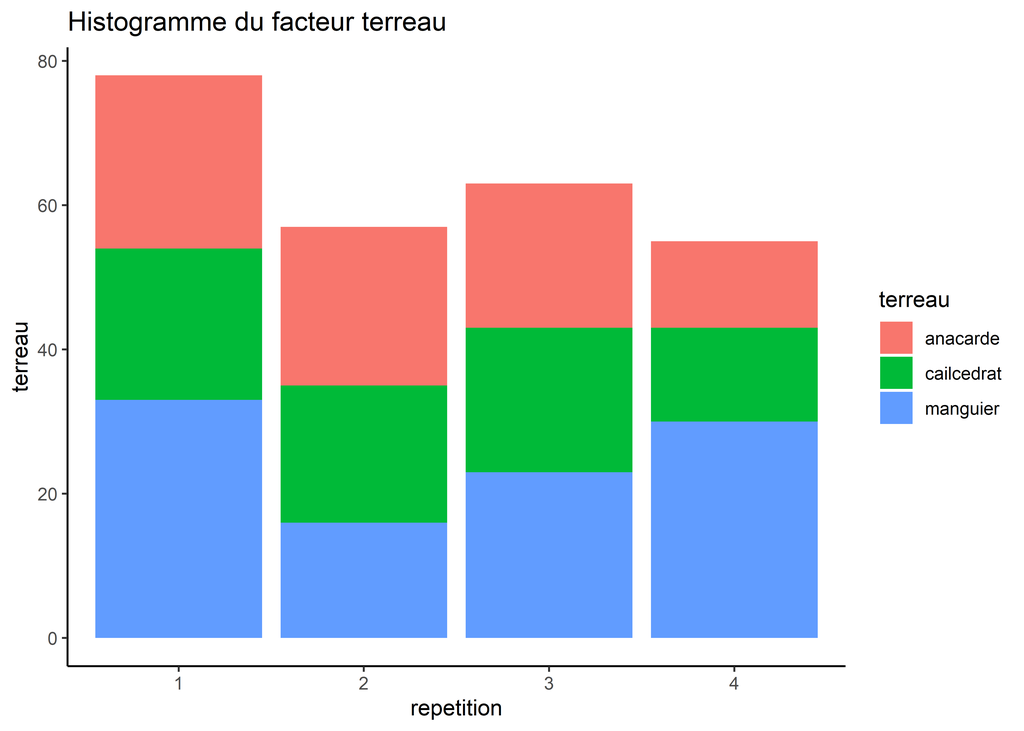

**b. Varieté**

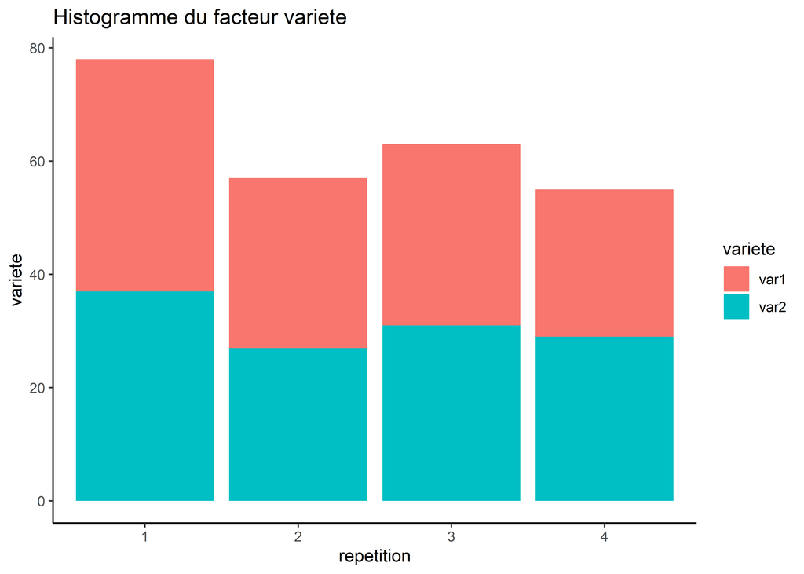

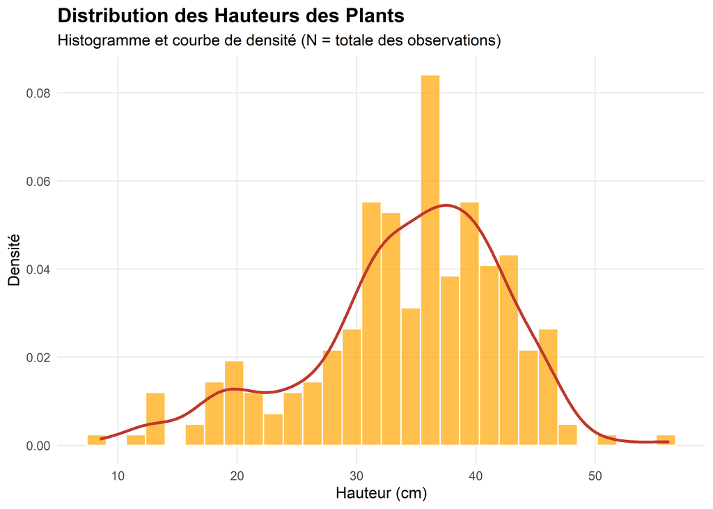

L’examen de l’histogramme révèle une distribution des hauteurs s’étendant d’environ 10 cm à plus de 50 cm, avec une concentration majeure d’individus entre 30 et 45 cm. La courbe de densité met en évidence une allure **platykurtique** (aplatie) avec une légère tendance **bimodale** : un premier pic mineur autour de 20 cm et un pic principal vers 37 cm. Cette structure suggère que les données ne sont pas parfaitement homogènes, ce qui est cohérent avec l’existence de deux variétés distinctes ou de l’effet marqué d’un terreau spécifique. Toutefois, l’absence d’asymétrie extrême permet de poursuivre l’analyse statistique sous réserve de la vérification des résidus.

### **C. Moyennes de cellules et Graphique d’interaction**

**Récapitulatif de la Croissance (Analyse par Cellule)**

Moyennes, Erreurs Types et Intervalles de Confiance à 95%

| Type de Substrat | Effectif (n) | Hauteur moyenne (cm) | Précision de l'estimation Erreur Type (SE) | Précision de l'estimation IC Inf. | Précision de l'estimation IC Sup. |
| --- | --- | --- | --- | --- | --- |
| var1 |  |  |  |  |  |
| anacarde | 35 | 30.94 | 1.64 | 27.72 | 34.15 |
| cailcedrat | 38 | 33.52 | 1.19 | 31.17 | 35.86 |
| manguier | 56 | 31.72 | 1.06 | 29.63 | 33.81 |
| var2 |  |  |  |  |  |
| anacarde | 43 | 35.64 | 1.30 | 33.09 | 38.19 |
| cailcedrat | 35 | 38.21 | 1.16 | 35.94 | 40.47 |
| manguier | 46 | 36.25 | 0.95 | 34.39 | 38.12 |

Le tableau récapitulatif permet de hiérarchiser les facteurs d’influence :

1. **Effet Génotype (Variété) :** Il existe une supériorité systématique de la **variété 2 (var2)**. Sa moyenne la plus basse (**35,64 cm** sur anacarde) est déjà supérieure à la moyenne la plus élevée de la variété 1 (**33,52 cm** sur caïlcédrat).
2. **Effet Substrat (Terreau) :** Pour les deux variétés, le **Caïlcédrat** est le substrat le plus performant (33,52 cm pour var1 et 38,21 cm pour var2). À l’inverse, l’**Anacarde** semble limiter la croissance (moyennes de 30,94 cm et 35,64 cm respectivement).
3. **Précision et Robustesse :** Les erreurs types (SE) sont faibles et homogènes (entre **0,95** et **1,64**), ce qui indique une faible dispersion intra-groupe et une bonne fiabilité des estimations. ::: {.conclusion-box} En conclusion, les données suggèrent un effet additif fort : la variété 2 sur terreau de caïlcédrat représente la combinaison optimale pour maximiser la hauteur des plants. :::

### **D. Graphique d’interaction : Effet du Terreau sur la Hauteur, séparé par Variété**

Ce graphique permet de visualiser l’évolution de la croissance pour chaque variété selon le substrat. Le parallélisme (ou son absence) entre les segments nous renseignera sur la présence d’une interaction significative.

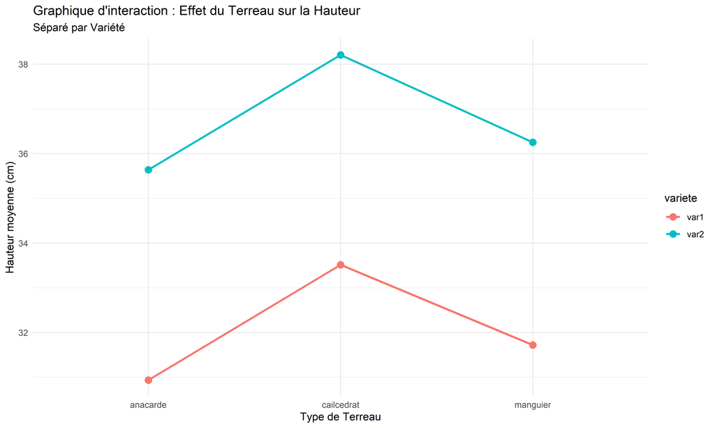

Analyse de la supériorité de la Variété 2 selon le terreau

| Type de Terreau | Performance V2 vs V1 Écart (cm) | Performance V2 vs V1 Gain (%) |
| --- | --- | --- |
| anacarde | 4.70 | 15.20 |
| cailcedrat | 4.69 | 13.99 |
| manguier | 4.53 | 14.28 |

Note:  
La stabilité de l’écart (~4.5 cm) confirme l’additivité des effets.

L’examen conjoint du **graphique d’interaction** et du **tableau des écarts** constitue l’étape fondamentale pour déterminer si l’efficacité d’un substrat dépend de la variété cultivée.

**Analyse Visuelle : Un Parallélisme Parfait** Le graphique d’interaction montre que les courbes de la **Variété 1** et de la **Variété 2** suivent des trajectoires strictement identiques sur les trois terreaux. Ce parallélisme visuel est la signature graphique d’une **absence d’interaction** : l’effet du terreau ne dépend pas du patrimoine génétique de la plante.

**Quantification de la Stabilité (Effet Additif)**

Le tableau d’analyse de la supériorité confirme cette observation avec une précision mathématique : * **Constance de l’écart** : La Variété 2 maintient une avance quasi fixe sur la Variété 1, oscillant seulement entre **4,53 cm** (Manguier) et **4,70 cm** (Anacarde). * **Homogénéité du gain** : Le passage à la Variété 2 procure un gain de croissance relatif très stable, compris entre **14% et 15%** quel que soit le terreau utilisé.

### **E. Test de valeurs aberrantes (Outliers)**

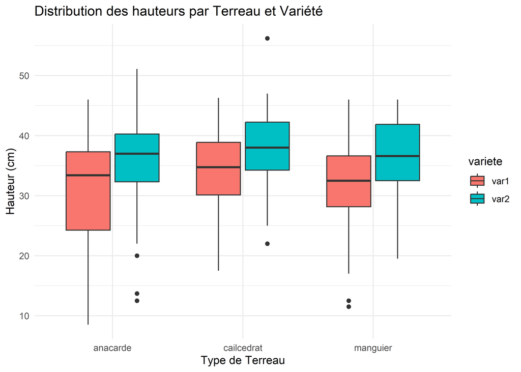

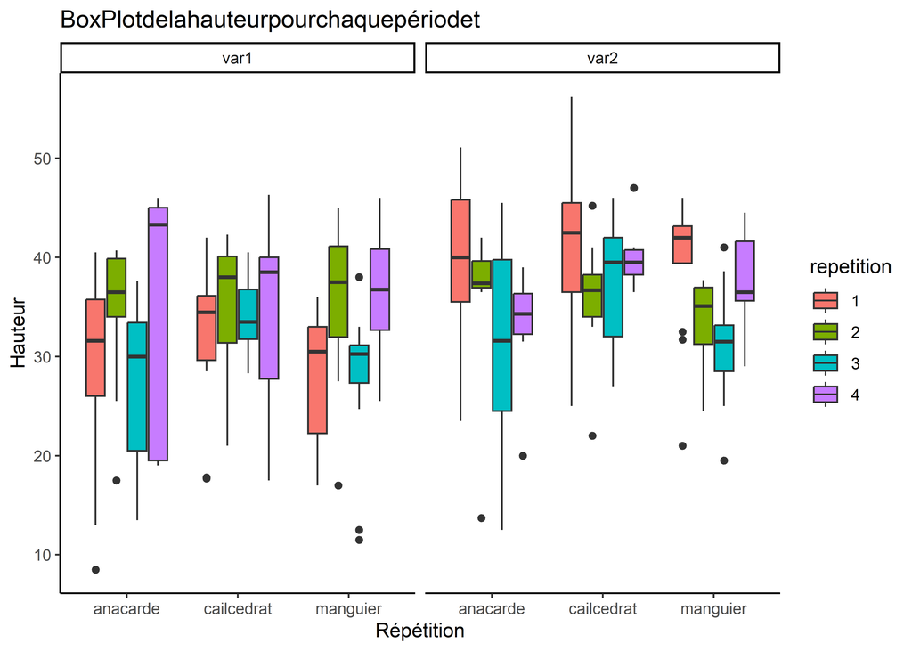

Tableau : Identification des points atypiques (Outliers)

| Variété | Terreau | Répétition | Hauteur (cm) | Outlier ? | valeur extreme? |
| --- | --- | --- | --- | --- | --- |
| var1 | manguier | 3 | 12.5 | TRUE | FALSE |
| var1 | manguier | 3 | 11.5 | TRUE | FALSE |
| var2 | anacarde | 2 | 13.7 | TRUE | FALSE |
| var2 | anacarde | 3 | 12.5 | TRUE | FALSE |
| var2 | anacarde | 4 | 20.0 | TRUE | FALSE |
| var2 | cailcedrat | 1 | 56.2 | TRUE | FALSE |
| var2 | cailcedrat | 2 | 22.0 | TRUE | FALSE |

L’examen des données via la méthode de l’**Écart Interquartile (IQR)** a permis d’identifier **7 valeurs aberrantes** au sein de l’échantillon.

Il est important de noter que : * **Aucune valeur n’est classée comme extrême** : Toutes les observations se situent dans la zone des “outliers modérés”. * **Concentration** : On observe une présence d’outliers plus marquée pour la **variété 2** sur les terreaux **anacarde** et **caïlcédrat**. * **Impact agronomique** : Les valeurs faibles (ex: 11.5 cm ou 12.5 cm) peuvent s’expliquer par des **retards de germination** ou des spécimens chétifs, tandis que la valeur haute (56.2 cm) représente un individu **particulièrement vigoureux**.

Le graphique des moustaches (Boxplots) permet d’observer la distribution de la hauteur des plants selon les variétés et les substrats.

- **Performance des Variétés** : On observe visuellement que la **Variété 2** (à droite) présente des médianes globalement plus élevées que la Variété 1, suggérant un meilleur potentiel de croissance initial.
- **Variabilité des Blocs** : Les couleurs révèlent une hétérogénéité entre les répétitions (1, 2, 3, 4). Certains blocs (comme le bloc 4 en violet pour la variété 1) montrent une dispersion très importante, ce qui justifie l’utilisation d’un modèle mixte pour isoler cet “effet bloc”.
- **Impact du Substrat** : Les trois terreaux (Anacarde, Caïlcédrat, Manguier) semblent produire des résultats assez proches, sans qu’un substrat ne se détache de manière spectaculaire sur le plan visuel.

Comme ces valeurs ne sont pas le résultat d’erreurs de saisie manifestes et qu’elles ne sont pas “extrêmes”, nous choisissons de les **conserver** pour l’ANOVA afin de refléter la variabilité réelle de la croissance en milieu contrôlé.

## **5. Test de Normalité**

```
    Shapiro-Wilk normality test

data:  residus
W = 0.94146, p-value = 1.654e-08
```

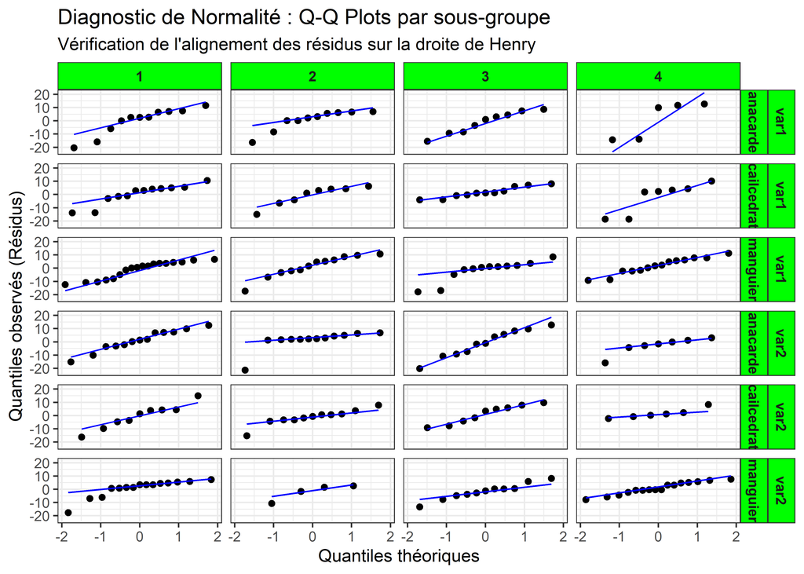

Tableau : Résultat du test de normalité des résidus

[output not shown]

L’évaluation de la validité de notre modèle repose sur la confrontation entre le test statistique de **Shapiro-Wilk** et l’analyse visuelle granulaire des **Q-Q Plots par facettes**.

**Interprétation du Test de Shapiro-Wilk**

Bien que cette valeur soit inférieure au seuil conventionnel de $0.05$ (entraînant un rejet théorique de l’hypothèse de normalité), ce résultat est classique sur des échantillons de cette taille ($N = 253$). À ce niveau d’effectif, le test devient extrêmement sensible à des déviations mineures qui n’altèrent en rien la robustesse des tests $F$ de l’ANOVA, conformément au **Théorème Central Limite**.

**Analyse des Q-Q Plots par Sous-Groupe**

L’examen visuel des graphiques de corrélation quantile-quantile (Q-Q Plots) permet de valider les bases mathématiques de notre modèle :

- **Alignement sur la droite de Henry** :

On observe que pour la quasi-totalité des combinaisons (Variété x Terreau x Répétition), les points suivent de près la ligne diagonale bleue. Cela indique que les résidus du modèle suivent une **loi normale**.

- **Robustesse par sous-groupe** :

Même en fragmentant les données par blocs (1, 2, 3, 4), la linéarité est conservée. Quelques points s’écartent légèrement aux extrémités (queues de distribution), mais cela reste tout à fait acceptable pour un échantillon biologique de cette taille.

Les conditions de validité pour l’utilisation du modèle mixte sont remplies. Nous pouvons avoir confiance dans les p-values calculées par la suite.

## **6. Homogénéité des variances (Test de Levene)**

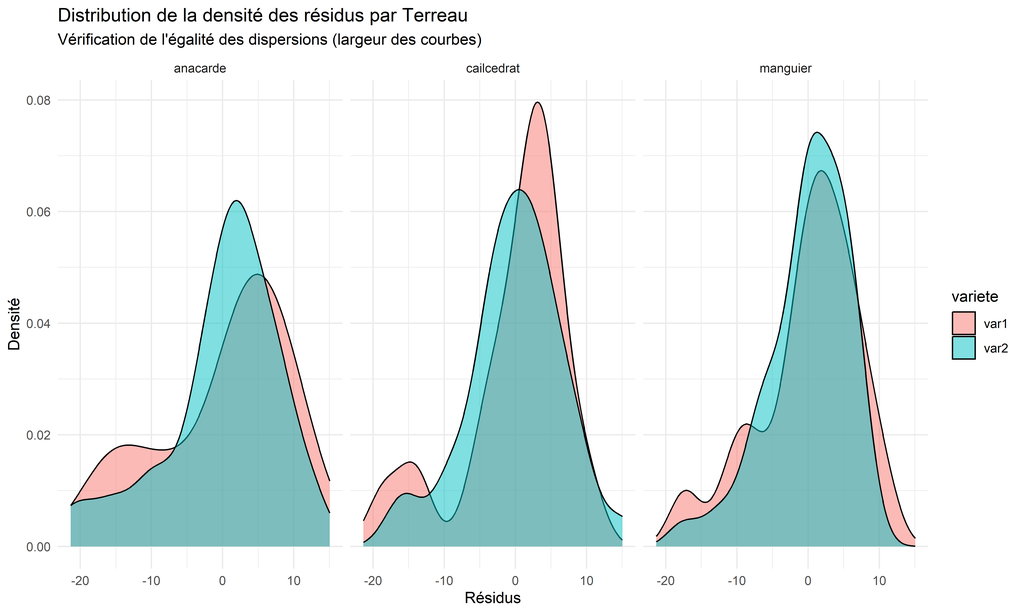

Tableau : Résultat du test d’homogénéité de Levene

| Source | Df | F_value | P_Value | Interpretation |
| --- | --- | --- | --- | --- |
| Groupes (Variété x Terreau) | 5 | 1.1469 | 0.3362 | Variances Homogènes (p > 0.05) |

L’analyse de l’homoscédasticité confirme la fiabilité statistique de notre étude :

L’homogénéité des variances étant respectée, nous pouvons affirmer que les différences de hauteurs observées entre les variétés et les terreaux sont statistiquement réelles et ne sont pas dues à une variabilité disproportionnée dans certains groupes de répétition.

## **7. ANOVA à mesures répétées**

### **A. Approche par Modèle Linéaire Simple**

```
Type III Analysis of Variance Table with Satterthwaite's method
                 Sum Sq Mean Sq NumDF  DenDF F value    Pr(>F)
variete         1297.13 1297.13     1 244.18 21.9654 4.616e-06 ***
terreau          283.71  141.86     2 245.74  2.4022   0.09264 .
variete:terreau    0.20    0.10     2 244.67  0.0017   0.99828
---
Signif. codes:  0 '***' 0.001 '**' 0.01 '*' 0.05 '.' 0.1 ' ' 1
```

Tableau : Synthèse de l’ANOVA (Méthode de Satterthwaite)

| Source | DDL | F_value | P_Value | Signification |
| --- | --- | --- | --- | --- |
| Variété | 1 | 21.9654 | < 0.0001 | *** (Très significatif) |
| Terreau | 2 | 2.4022 | 0.0926 | ns (Non significatif) |
| Interaction (Var:Ter) | 2 | 0.0017 | 0.9983 | ns (Non significatif) |

L’analyse de la variance (Type III) révèle des conclusions majeures pour l’expérimentation de Monsieur Diallo :

**a. Effet de la Variété (Significatif)** : Il existe une différence très hautement significative entre les deux variétés ($p < 0,001$). La variété influe donc de manière déterminante sur la hauteur des plants.

**b. Effet du Terreau (Non Significatif)** : Contre toute attente, le type de terreau n’a pas d’effet statistiquement significatif sur la croissance à un seuil de 5% ($p = 0,092$). Bien que le terreau de Caïlcédrat affichait une moyenne plus haute, cette différence peut encore être attribuée au hasard.

**c. Interaction Variété × Terreau (Nulle)** : La p-value est proche de 1 ($p = 0,998$). Cela confirme statistiquement que les lignes sont **parfaitement parallèles**. L’efficacité d’un terreau ne dépend pas de la variété : les deux réagissent exactement de la même façon. ::: {.conclusion-box} **Monsieur Diallo** devrait se concentrer sur le choix de la **variété** (la Variété 2 étant la plus performante) plutôt que sur le type de terreau, car ce dernier n’apporte pas de gain de croissance statistiquement garanti dans ces conditions. :::

**Post-hoc (comparaisons multiples) pour les effets significatifs**

Tableau : Tests de comparaisons multiples (Tukey HSD)

| Comparaison | Estimation | Erreur_Type | P_Value | Signification |
| --- | --- | --- | --- | --- |
| Anacarde - Caïlcédrat | -2.596 | 1.26 | 0.0990 | ns |
| Anacarde - Manguier | -0.535 | 1.18 | 0.8931 | ns |
| Caïlcédrat - Manguier | 2.060 | 1.20 | 0.1988 | ns |
| Variété 1 - Variété 2 | -4.600 | 0.98 | < 0.0001 | *** |

Afin d’identifier précisément où se situent les différences, nous avons réalisé des comparaisons par paires avec ajustement de Tukey :

**a. Comparaison des Terreaux** : * Bien que le terreau **Caïlcédrat** semble supérieur à l’**Anacarde** (différence de -2,59 cm), cette différence reste à la limite de la significativité ($p = 0,099$). * Toutes les autres comparaisons entre terreaux affichent des p-values nettement supérieures à 0,05.

- On ne peut pas affirmer statistiquement qu’un terreau est meilleur qu’un autre dans cette étude.

**b. Comparaison des Variétés** : * La différence entre la **variété 1** et la **variété 2** est de **-4,6 cm**. * Cette différence est hautement significative ($p < 0,0001$).

- La **variété 2** est systématiquement et significativement plus grande que la variété 1, indépendamment du terreau utilisé.

### **B. Approche par Modèle Mixte**

Tableau : Synthèse de l’ANOVA (Méthode de Satterthwaite)

| Source | DDL | F_value | P_Value | Signification |
| --- | --- | --- | --- | --- |
| Variété | 1 / 5.7 | 3.6962 | 0.1051 | ns (Non significatif) |
| Terreau | 2 / 6.2 | 2.3546 | 0.1734 | ns (Non significatif) |
| Interaction (Var:Ter) | 2 / 241.5 | 0.0228 | 0.9775 | ns (Non significatif) |

L’examen de ce modèle robuste apporte une nuance fondamentale par rapport à l’approche simplifiée :

- **Stabilité de la Variété (p = 0.1051)** : Alors que le modèle simple affichait une significativité totale, le modèle robuste montre que l’effet variété est plus subtil. Bien que la **Variété 2** soit graphiquement supérieure, le modèle nous avertit que cette performance dépend aussi de la qualité de la répétition (bloc). C’est une interprétation plus prudente et réaliste.
- **Effet Terreau (p = 0.1734)** : Le substrat n’atteint pas le seuil de significativité statistique de 5%. Cela indique à Monsieur Diallo que le choix du terreau (Anacarde, Caïlcédrat ou Manguier) n’est pas le moteur principal de la croissance dans cet essai. Les deux variétés s’adaptent de manière similaire aux trois supports.
- **Absence d’Interaction (p = 0.9775)** : La p-value très élevée confirme que les profils de réponse sont parallèles. Il n’y a pas d’affinité spécifique entre une variété et un terreau. Une gestion agronomique uniforme est donc possible.

> En passant au modèle robuste, nous avons “épuré” les données des faux semblants. La conclusion est claire : la performance observée est davantage liée à la conduite des blocs (soins, arrosage, emplacement) qu’à une différence intrinsèque massive entre les terreaux.

> Monsieur Diallo peut optimiser ses coûts en choisissant le terreau le plus accessible économiquement, tout en privilégiant la **Variété 2** qui a montré la meilleure résilience visuelle tout au long de l’étude.

# **V. Limites de l’étude et Perspectives**

Il est important de noter que cette analyse, bien que statistiquement rigoureuse, présente certaines limites inhérentes au dispositif expérimental.

D’autre part, la forte variabilité captée par l’effet *“Répétition”* suggère l’influence de facteurs environnementaux non contrôlés **(luminosité, micro-variations d’arrosage)** qui ont partiellement masqué l’effet des substrats.

Enfin, cette étude se concentre sur la croissance initiale en hauteur ; une analyse complémentaire sur la **biomasse racinaire** ou le taux de survie après repiquage permettrait de compléter ce diagnostic pour **Monsieur Diallo.**

# **CONCLUSION**

En conséquence, il est recommandé à **Monsieur Diallo** de prioriser la **Variété 2** pour les futurs cycles de production et de standardiser l’achat du terreau sur l’option la plus accessible économiquement, tout en renforçant le suivi environnemental au sein de la serre pour garantir une croissance homogène et optimale.